# DATA-413/613

Tidyverse 4

Hamid Semiyari

2024-06-25

# 1 Factors

- A “factor” is R’s way to say that a variable is categorical (puts observational/experimental units into different groups or categories based on their values.).
- A factor is different from a character in that:
  1. There is a small predefined set of “levels” (possible values) of a factor, but not of a character.
  2. There is an ordering for the levels of a factor
     - Useful when determining the order to plot something.
     - Useful when doing ordered logistic regression.
- Consider the following data frame for average highs in DC for each month.

```r
    library(tidyverse)
    dcclimate <- tribble(~month, ~avehigh,
                         ##----/---------
                         "Jan",  43.4,
                         "Feb",  47.1,
                         "Mar",  55.9,
                         "Apr",  66.6,
                         "May",  75.4,
                         "Jul",  88.4,
                         "Aux",  86.5,
                         "Sep",  79.5,
                         "Oct",  68.4,
                         "Nov",  57.9,
                         "Dec",  46.8)
```

- The weather for June is missing and the 3-letter abbreviation for August is incorrect. We would like to notice both of these.
- Also, when we plot the data, we would prefer the order to be the same as that for the order of the months of the year.

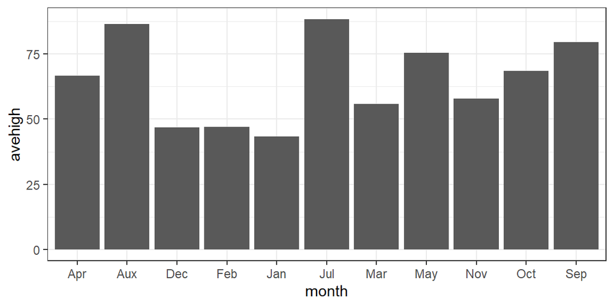

```r
    ggplot(dcclimate, aes(x = month, y = avehigh)) +
      geom_col()
```

- Factors help us with all of these issues.
- You have to be **very** careful about factors.

```r
    x  <- c("51", "32", "15", "2", "32")
    xf <- factor(x)
    xf
```

```
## [1] 51 32 15 2  32
## Levels: 15 2 32 51
```

```r
    as.numeric(x)
```

```
## [1] 51 32 15  2 32
```

```r
    class(as.numeric(xf))
```

```
## [1] "numeric"
```

```r
    as.numeric("Hello")
```

```
## [1] NA
```

```r
    as.numeric(factor("Hello"))
```

```
## [1] 1
```

```r
    fac1 <- factor(c("x1", "x2", "x3"))
    fac2 <- factor(c("y1", "y2", "y3"))
    c(fac1, fac2)
```

```
## [1] x1 x2 x3 y1 y2 y3
## Levels: x1 x2 x3 y1 y2 y3
```

- If you are 100% sure that all levels are numerics and are incorrectly specified as factors, then do the following to convert to numeric:

```r
xf
```

```
## [1] 51 32 15 2  32
## Levels: 15 2 32 51
```

```r
    parse_number(levels(xf)[xf]) ->
  nb
nb
```

```
## [1] 51 32 15  2 32
```

```r
class(nb)
```

```
## [1] "numeric"
```

## 1.1 Creating Factors

- Use `factor()` or `parse_factor()` to create a factor variable
- `parse_factor()` returns better warnings, so I would recommend always using that.

```r
    monthvec <- c("Jan", "Feb", "Mar", "Apr", "May", "Jun",
                  "Jul", "Aug", "Sep", "Oct", "Nov", "Dec")
    dcclimate %>%
      mutate(monthfc = factor(month, levels = monthvec)) ->
      dcclimate

    dcclimate %>%
      mutate(monthfc2 = parse_factor(month, levels = monthvec)) ->
      dcclimate
```

```
## Warning: There was 1 warning in `mutate()`.
## ℹ In argument: `monthfc2 = parse_factor(month, levels = monthvec)`.
## Caused by warning:
## ! 1 parsing failure.
## row col           expected actual
##   7  -- value in level set    Aux
```

```r
    dcclimate$monthfc
```

```
##  [1] Jan  Feb  Mar  Apr  May  Jul  <NA> Sep  Oct  Nov  Dec
## Levels: Jan Feb Mar Apr May Jun Jul Aug Sep Oct Nov Dec
```

- If you do not specify the `levels` argument, R will assume that the levels are the unique values of the vector.
  - `factor()` takes the order of the levels to be the same order returned by `sort()`.
  - `parse_factor()` takes the order of the levels to be the same order as the order of the value introduced.

```r
    x <- c("A", "string", "vector", "is", "a", "string", "vector")
    factor(x)
```

```
## [1] A      string vector is     a      string vector
## Levels: a A is string vector
```

```r
    sort(unique(x))
```

```
## [1] "a"      "A"      "is"     "string" "vector"
```

```r
    parse_factor(x)
```

```
## [1] A      string vector is     a      string vector
## Levels: A string vector is a
```

- You can always see the levels of a factor (and their order) using the `levels()` function

```r
    levels(dcclimate$monthfc)
```

```
##  [1] "Jan" "Feb" "Mar" "Apr" "May" "Jun" "Jul" "Aug" "Sep" "Oct" "Nov" "Dec"
```

- Other options are the `fct_unique()` and `fct_count()` functions from the forcats package.

```r
    fct_unique(dcclimate$monthfc)
```

```
##  [1] Jan  Feb  Mar  Apr  May  Jun  Jul  Aug  Sep  Oct  Nov  Dec  <NA>
## Levels: Jan Feb Mar Apr May Jun Jul Aug Sep Oct Nov Dec
```

```r
    fct_count(dcclimate$monthfc)
```

```
## # A tibble: 13 × 2
##    f         n
##    <fct> <int>
##  1 Jan       1
##  2 Feb       1
##  3 Mar       1
##  4 Apr       1
##  5 May       1
##  6 Jun       0
##  7 Jul       1
##  8 Aug       0
##  9 Sep       1
## 10 Oct       1
## 11 Nov       1
## 12 Dec       1
## 13 <NA>      1
```

- You can count the number of levels with `nlevels()`.

```r
    nlevels(dcclimate$monthfc)
```

```
## [1] 12
```

- Once we have a factor variable, the order of the aesthetic map is set in ggplot.

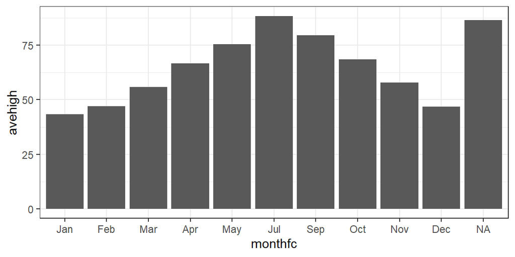

```r
    ggplot(dcclimate, aes(x = monthfc, y = avehigh)) +
      geom_col()
```

- We can include missing levels by using the `drop = FALSE` argument in the appropriate scale call:

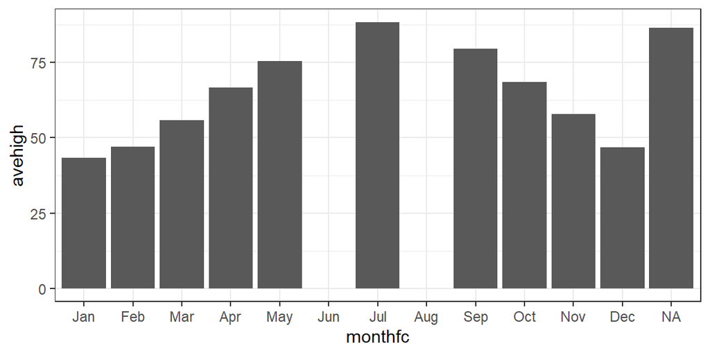

```r
    ggplot(dcclimate, aes(x = monthfc, y = avehigh)) +
      geom_col() +
      scale_x_discrete(drop = FALSE)
```

## 1.2 forcats

- forcats is an R package which makes two things much easier in R:
  - Changing the order of the levels of the factor variable.
  - Changing the levels of the factor variable.
- It also a few other helper functions for factors.
- All forcat functions begin with `fct_`. So you can type “fct_” then use tab-completion to scroll through the possible functions.
- forcats is a part of the tidyverse, so you don’t need to load it separately when you load the tidyverse.

### 1.2.1 Changing the Order of the Levels

- Consider the subset of the [General Social Survey](https://en.wikipedia.org/wiki/General_Social_Survey) stored in the `gss_cat` data in forcats.

```r
    data(gss_cat)
    glimpse(gss_cat)
```

```
## Rows: 21,483
## Columns: 9
## $ year    <int> 2000, 2000, 2000, 2000, 2000, 2000, 2000, 2000, 2000, 2000, 20…
## $ marital <fct> Never married, Divorced, Widowed, Never married, Divorced, Mar…
## $ age     <int> 26, 48, 67, 39, 25, 25, 36, 44, 44, 47, 53, 52, 52, 51, 52, 40…
## $ race    <fct> White, White, White, White, White, White, White, White, White,…
## $ rincome <fct> $8000 to 9999, $8000 to 9999, Not applicable, Not applicable, …
## $ partyid <fct> "Ind,near rep", "Not str republican", "Independent", "Ind,near…
## $ relig   <fct> Protestant, Protestant, Protestant, Orthodox-christian, None, …
## $ denom   <fct> "Southern baptist", "Baptist-dk which", "No denomination", "No…
## $ tvhours <int> 12, NA, 2, 4, 1, NA, 3, NA, 0, 3, 2, NA, 1, NA, 1, 7, NA, 3, 3…
```

- You often want to change the order of the levels of a factor to make plots more insightful.

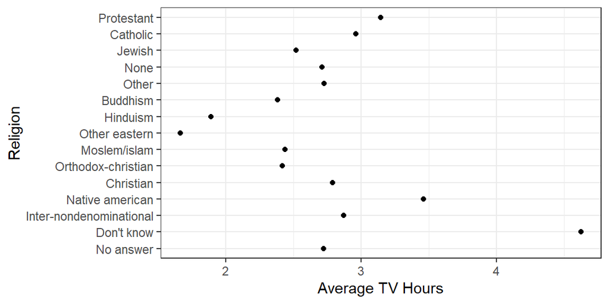

```r
    gss_cat %>%
      group_by(relig) %>%
      summarize(tvhours_mean = mean(tvhours, na.rm = TRUE)) ->
      tvdat

    ggplot(tvdat, aes(x = tvhours_mean, y = relig)) +
      geom_point() +
      xlab("Average TV Hours") +
      ylab("Religion")
```

- `fct_reorder()` reorders the levels of a factor according to some values of another variable. The arguments are:
  - `f`: The factor vector.
  - `x`: A numeric vector used to reorder the levels.
  - `fun`: A function applied to `x`, the result of which will be used to order the levels of `f`.

```r
    levels(tvdat$relig)
```

```
##  [1] "No answer"               "Don't know"
##  [3] "Inter-nondenominational" "Native american"
##  [5] "Christian"               "Orthodox-christian"
##  [7] "Moslem/islam"            "Other eastern"
##  [9] "Hinduism"                "Buddhism"
## [11] "Other"                   "None"
## [13] "Jewish"                  "Catholic"
## [15] "Protestant"              "Not applicable"
```

```r
    tvdat %>%
      mutate(relig = fct_reorder(relig, tvhours_mean)) ->
      tvdat
    levels(tvdat$relig)
```

```
##  [1] "Other eastern"           "Hinduism"
##  [3] "Buddhism"                "Orthodox-christian"
##  [5] "Moslem/islam"            "Jewish"
##  [7] "None"                    "No answer"
##  [9] "Other"                   "Christian"
## [11] "Inter-nondenominational" "Catholic"
## [13] "Protestant"              "Native american"
## [15] "Don't know"              "Not applicable"
```

- The plot now reorders the y-axis according to the new level order.

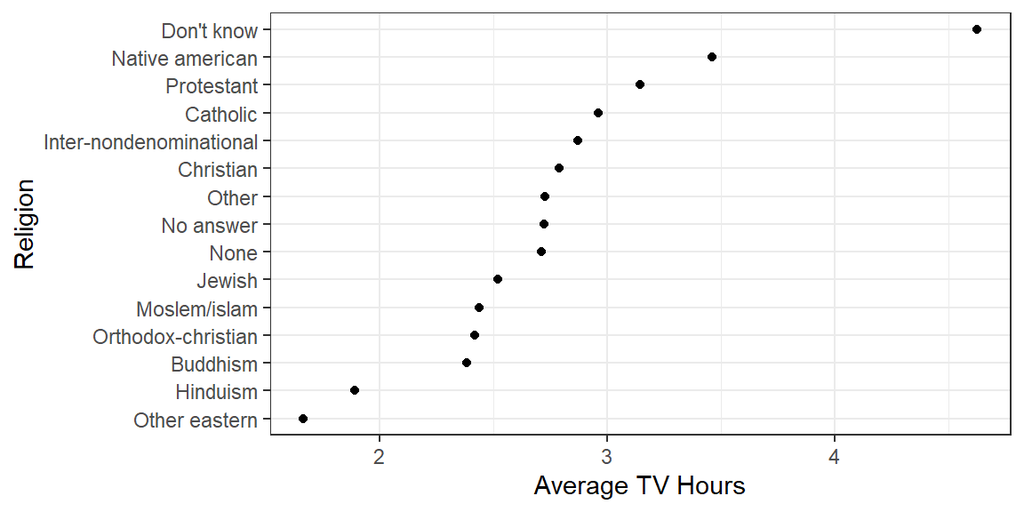

```r
    ggplot(tvdat, aes(x = tvhours_mean, y = relig)) +
      geom_point() +
      xlab("Average TV Hours") +
      ylab("Religion")
```

- `fct_rev()` reverses the order of the factors.

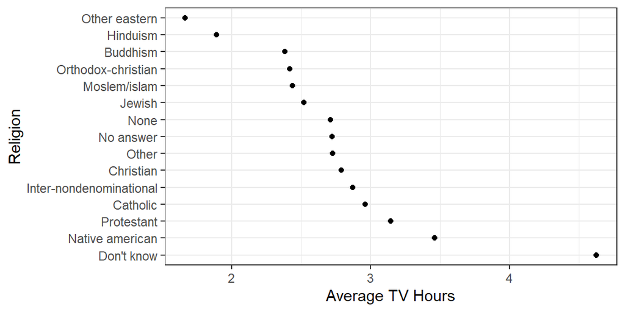

```r
    tvdat %>%
      mutate(relig = fct_rev(relig)) %>%
      ggplot(aes(x = tvhours_mean, y = relig)) +
        geom_point() +
        xlab("Average TV Hours") +
        ylab("Religion")
```

- `fct_relevel()` allows you to move existing levels to any location.

```r
    ## Moves "None" to first level
    fct_relevel(tvdat$relig, "None") %>%
      levels()
```

```
##  [1] "None"                    "Other eastern"
##  [3] "Hinduism"                "Buddhism"
##  [5] "Orthodox-christian"      "Moslem/islam"
##  [7] "Jewish"                  "No answer"
##  [9] "Other"                   "Christian"
## [11] "Inter-nondenominational" "Catholic"
## [13] "Protestant"              "Native american"
## [15] "Don't know"              "Not applicable"
```

```r
    ## Moves "None" to the third level
    fct_relevel(tvdat$relig, "None", after = 2L) %>%
      levels()
```

```
##  [1] "Other eastern"           "Hinduism"
##  [3] "None"                    "Buddhism"
##  [5] "Orthodox-christian"      "Moslem/islam"
##  [7] "Jewish"                  "No answer"
##  [9] "Other"                   "Christian"
## [11] "Inter-nondenominational" "Catholic"
## [13] "Protestant"              "Native american"
## [15] "Don't know"              "Not applicable"
```

```r
    ## Moves "None" to the last level
    fct_relevel(tvdat$relig, "None", after = nlevels(tvdat$relig)) %>%
      levels()
```

```
##  [1] "Other eastern"           "Hinduism"
##  [3] "Buddhism"                "Orthodox-christian"
##  [5] "Moslem/islam"            "Jewish"
##  [7] "No answer"               "Other"
##  [9] "Christian"               "Inter-nondenominational"
## [11] "Catholic"                "Protestant"
## [13] "Native american"         "Don't know"
## [15] "Not applicable"          "None"
```

```r
    ## Returns a warning because "Cthulhuism" is not a level
    fct_relevel(tvdat$relig, "Cthulhuism")
```

```
##  [1] No answer               Don't know              Inter-nondenominational
##  [4] Native american         Christian               Orthodox-christian
##  [7] Moslem/islam            Other eastern           Hinduism
## [10] Buddhism                Other                   None
## [13] Jewish                  Catholic                Protestant
## 16 Levels: Other eastern Hinduism Buddhism Orthodox-christian ... Not applicable
```

### 1.2.2 Modify Factor Levels

- Let’s look at the levels of `partyid` in `gss_cat`.

```r
    levels(gss_cat$partyid)
```

```
##  [1] "No answer"          "Don't know"         "Other party"
##  [4] "Strong republican"  "Not str republican" "Ind,near rep"
##  [7] "Independent"        "Ind,near dem"       "Not str democrat"
## [10] "Strong democrat"
```

- Use `fct_recode()` to change the levels.

```r
    gss_cat %>%
      mutate(partyid = fct_recode(partyid,
                                  "Republican, strong"    = "Strong republican",
                                  "Republican, weak"      = "Not str republican",
                                  "Independent, near rep" = "Ind,near rep",
                                  "Independent, near dem" = "Ind,near dem",
                                  "Democrat, weak"        = "Not str democrat",
                                  "Democrat, strong"      = "Strong democrat"
                                  )) ->
      gss_cat
    levels(gss_cat$partyid)
```

```
##  [1] "No answer"             "Don't know"            "Other party"
##  [4] "Republican, strong"    "Republican, weak"      "Independent, near rep"
##  [7] "Independent"           "Independent, near dem" "Democrat, weak"
## [10] "Democrat, strong"
```

- New level goes on the left of the equals sign. Old level goes on the right. (Just like `mutate()`!)
- **Exercise**: Modify the factor levels of `marital` to be abbreviations of their long-names. For example, “Divorced” can just be “D”

## 1.3 Other Useful Functions.

- `fct_c()`: is the safe way to combine factor vectors.

```r
    fc1 <- parse_factor(c("A", "B"))
    fc1
```

```
## [1] A B
## Levels: A B
```

```r
    fc2 <- parse_factor(c("C", "D"))
    fc2
```

```
## [1] C D
## Levels: C D
```

```r
    fct_c(fc1, fc2)
```

```
## [1] A B C D
## Levels: A B C D
```

- `fct_collapse()`: combine multiple levels into one level.

```r
    fc <- parse_factor(c("A", "B", "C", "A", "B", "C"))
    fc
```

```
## [1] A B C A B C
## Levels: A B C
```

```r
    fct_collapse(fc, "blah" = c("A", "B"))
```

```
## [1] blah blah C    blah blah C
## Levels: blah C
```

- `fct_drop()`: removes any levels that are unused.

```r
    fc <- parse_factor(c("A", "B"), levels = c("A", "B", "C"))
    fc
```

```
## [1] A B
## Levels: A B C
```

```r
    fct_drop(fc)
```

```
## [1] A B
## Levels: A B
```

- `fct_expand()`: adds a new level.

```r
    fc <- parse_factor(c("A", "B"))
    fc
```

```
## [1] A B
## Levels: A B
```

```r
    fct_expand(fc, "C")
```

```
## [1] A B
## Levels: A B C
```

- `fct_infreq()`: Order by frequency of a level.

```r
    fc <- parse_factor(c("A", "B", "C", "B", "C", "C"))
    fct_count(fc)
```

```
## # A tibble: 3 × 2
##   f         n
##   <fct> <int>
## 1 A         1
## 2 B         2
## 3 C         3
```

```r
    fct_infreq(fc) %>%
      fct_count()
```

```
## # A tibble: 3 × 2
##   f         n
##   <fct> <int>
## 1 C         3
## 2 B         2
## 3 A         1
```